# Small Models, Large Data, and the Unglamorous Work in Between

AI and machine learning in applied settings

Corey Sparks

Department of Sociology and Demography, UT San Antonio

2026-10-21

## My Background

Biological Anthropologist first, then statistics

Left academia in 2023 for greener pastures…. *VERY* interesting industry experience

Professor of Demography Focus on Bayesian models and use of AI tools

## Three uses of AI that got me started

Small local models Turn a pile of documents into structured features for audience and market fit analysis.

A technical collaborator ChatGPT and Claude Code helped me design and debug data systems I was never trained to build.

Synthetic data AI-generated stand-ins that carried two analyst training courses without confidential records.

Each one needs a different kind of checking.

## The setting: Coleridge and the ADRF

State agency staff, linked administrative records, and policy questions.

Workforce, postsecondary education, corrections, public benefits, and quarterly earnings.

Training and reproducible materials in R, SQL, and Python.

Administriative Data Research Facility -> FEDRAMP Secure AWS workspace

The default rule: sensitive data does not leave the controlled environment and NO AI is allowed in.

## Before anyone fits a model

“Does the real world program work?”

Define the cohort.

Pick a time origin.

Link records across systems that were never built to talk to each other.

Build pre- and post-program measures.

Decide what comparison answers the question.

The population at risk, the exposure window, the denominator.

## What “small model” means here

Encoder models Sentence embeddings turn text into vectors. Zero-shot classifiers score text against labels you supply.

Often a few hundred million parameters. Runs on a laptop GPU or a CPU. Deterministic and easy to audit.

I used `all-MiniLM-L6-v2` for embeddings and `bart-large-mnli` for zero-shot.

Small generative models Roughly 0.6 to 9 billion parameters, quantized, served locally through Ollama or LM Studio. llama3.2:3b did wonders for me.

I also tried `mistral:7b`, `qwen2.5:3b`, and `qwen3:0.6b`.

Reached from R with `ellmer` and from Python with `ollama`. Same client code can point at a hosted endpoint later.

## The hardware was not a GPU cluster

Remember: Small company with low resources!

Laptop 1 RTX 4060, 8 GB of VRAM.

Room for quantized models up to about 7 to 9B parameters.

Laptop 2 Integrated graphics, Lots of RAM.

The 3B class, after new thermal paste so it would stop cooking itself.

# Audience and market analysis

## The question

Who is in the pool of people we train or want to reach?

What skills and roles recur? Are there distinct groups that need different examples, training, or outreach?

The business use: find new training product opportunities.

## Two corpora

Resumes and CVs Collected from past training classes on a shared drive.

Who are our participants? Degrees, fields, titles, skills, sectors, years of experience.

Application statements 908 documents: 337 personal statements, 245 supervisor statements, 118 letters of support, and others.

Why do they come, and what do they hope to learn?

## The pipeline

```
flowchart LR
  A[PDF and DOCX<br/>resumes] --> B[Extract fields<br/>degree, field, titles,<br/>skills, sector, experience]
  B --> C[persona_text<br/>short summary<br/>per person]
  C --> D[Route 1<br/>zero-shot classification<br/>analyst labels]
  C --> E[Route 2<br/>embeddings and<br/>clustering]
  D --> F[Read, validate,<br/>name segments]
  E --> F
  classDef mid fill:#032044,color:#FFFFFF,stroke:#032044
  classDef org fill:#F15A22,color:#032044,stroke:#F15A22
  classDef mist fill:#C8DCFF,color:#032044,stroke:#265BF7
  class A,B,C mid
  class D,E mist
  class F org
```

## Two routes to structure

Classify A zero-shot classifier scores each persona against labels such as sectors or role types.

The analyst supplies the labels. The model does not invent them.

Works when you already trust the taxonomy.

Discover An embedding model turns each persona into a vector. Clustering groups similar backgrounds.

Then the real work: read common titles and skills, read representative resumes, name the groups.

## “Can the classifier just make its own labels?”

No, and the reason is the lesson.

Classifying against a fixed frame and discovering new categories are different measurement operations.

If you want proposed labels, you need a different step: a generative model that names clusters, or an analyst who reads them.

## How the pipeline evolved

```
flowchart LR
  A[Regex and<br/>keyword<br/>rules] --> B[Zero-shot<br/>classifier]
  B --> C[Local<br/>0.6B to 7B<br/>models]
  C --> D[Hosted<br/>Claude with<br/>redaction]
  D --> E[Multi-agent<br/>review]
  classDef mid fill:#032044,color:#FFFFFF,stroke:#032044
  classDef mist fill:#C8DCFF,color:#032044,stroke:#265BF7
  classDef org fill:#F15A22,color:#032044,stroke:#F15A22
  class A,B,C mid
  class D mist
  class E org
```

Each step was a response to what the previous one got wrong.

Local first, then hosted when quality mattered more than the cost of redaction and review.

## What went wrong

A Word file was silently skipped while the PDFs were processed. The corpus was smaller than I thought.

Missing `persona_text` and `cluster` columns, because one step did not write what the next step expected.

Python scope and indentation errors. This is what happens when an R person writes Python.

One script never ran again after a bad paste: `MODEL = "mistral:7b"rom resume_files/...`

The model call is the one part of the pipeline that almost never breaks.

## What the small model got wrong

Five test resumes, two of them my own, run through `qwen3:0.6b`:

| Cluster | n | Extracted “titles” |
| --- | --- | --- |
| 0 | 2 | decision science leader, director-caliber, applied demography, **university of texas at san antonio, dr. corey sparks** |
| 1 | 2 | assistant professor, associate professor, mentor, assistant researcher |
| 2 | 1 | *(empty: every field “unknown”)* |

A name and an employer landed in the job titles field. One document produced nothing, and still got its own cluster.

Three clusters from five documents. The method ran. The answer meant nothing.

## Prompting a small generative model

When a generative model extracts fields or names clusters, the prompt has to fit the model.

Short instructions. A small closed set of choices. Temperature zero. Structured output it cannot wander away from.

Defensive plumbing around the call: a **repair pass** that sends malformed JSON back to the model to fix, and truncation that keeps the start and end of long resumes so the skills section survives.

Write a frontier-model prompt and a 3B model will ignore half of it.

## The naming trap

“Experienced professionals seeking growth opportunities”

Model-written segment descriptions drift toward generic marketing language that sounds plausible and says nothing.

A multi-agent review with four roles: an orchestrator, a profiler, a strategist, and a **critic** whose only job is to flag vague claims, inconsistencies, and over-generalization.

It ran on the real segmentation outputs, with hosted models: Claude Sonnet for the orchestrator, profiler, and critic, and Opus for the strategist. Its job was to review what the other models produced.

# Evaluation, honestly

## Read your outputs

Small scale and mostly manual: I read outputs, compared labels with my own judgment on samples, and kept notes on the failures.

Names and employers in the wrong fields. Empty extractions that still get clustered. Fluent persona descriptions that would fit anyone.

Every automated metric you build later formalizes judgments like these. If you never made them by hand, you do not know what the metric measures.

## Checks for clustering

Count the files read against the files you meant to read.

Look at the extracted text for several documents. Extraction fails quietly.

Compare cluster assignments with the actual resumes.

Look for duplicate profiles.

Change the number of clusters. Do the groups stay interpretable or dissolve?

Do the segments answer a real training or outreach question?

## A model-generated label is a measurement

Measurements have error.

Build a hand-coded validation sample. Compute a misclassification matrix. Report precision and recall **by category**.

A classifier that is 90 percent accurate overall can still be useless for the one category you care about.

A cluster with a convincing name is a hypothesis about a social type, not evidence that the type exists.

## The cohort year was a file timestamp

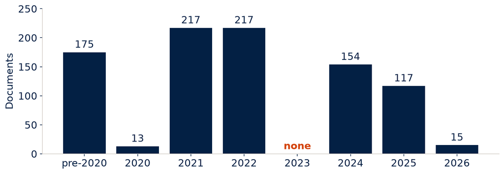

The model then wrote confident trend claims: “the 2021 cohort marks a visible inflection point.”

The data problem was upstream of every model.

## Local is not a license

Running locally keeps document text away from hosted services. That shortens the governance conversation a lot.

PII on your laptop is still PII.

## Redaction is a process, not a function

When the pipeline moved to a hosted model, I wrote a redaction step: emails, phones, URLs, addresses, and person names via spaCy.

Names still got through, in two places:

The output file saved the first 2,000 characters of each resume **before** redaction.

The statement script asked the model to return each applicant’s name, so the model-written summaries name real people.

Check every place text is written, not just the place it is sent.

# AI as a collaborator in data engineering

## It compressed the learning cycle

My training is in demography and anthropology, not data engineering.

Designing tables. Translating among R, SQL, and Python. Debugging Redshift queries against large administrative schemas. SQL to `dbplyr` translations that did not match at first.

All in the ADRF, LOTS of screenshots of schemas and small spreadsheet examples.

The assistant proposed code and explained errors. I still had to set the grain of every table, decide which tables have primacy, and decide who belonged in the cohort.

## The wage window bug

Looks right, is wrong

```sql
-- starts from the program table
SELECT p.person_id,
  COALESCE(SUM(w.wages), 0)
    AS post_wages
FROM program p
LEFT JOIN wages w
  ON w.person_id = p.person_id
 AND w.quarter BETWEEN
     p.exit_qtr + 1 AND p.exit_qtr + 4
GROUP BY p.person_id;
-- people with no program record
-- later become zeros
```

Matches the design

```sql
-- starts from the cohort
SELECT c.person_id,
  SUM(w.wages)   AS post_wages,
  COUNT(w.wages) AS n_qtrs
FROM cohort c
LEFT JOIN wages w
  ON w.person_id = c.person_id
 AND w.quarter BETWEEN
     c.ref_qtr + 1 AND c.ref_qtr + 4
GROUP BY c.person_id;
-- common reference quarter,
-- missing stays missing
```

## How big is the damage? A simulation

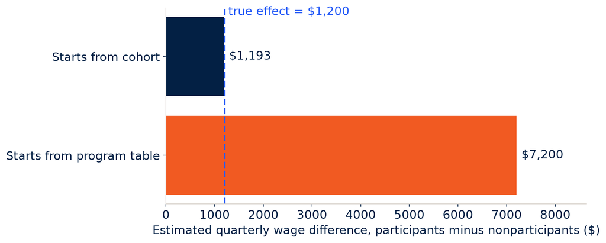

## The lesson from the bug

A query that runs is the first check. A query that runs and gives plausible numbers is the dangerous one.

The model supplied candidate code and explanations. Domain knowledge and validation decided whether the result meant what we thought it meant.

Best to compare notes with domain experts and data providers.

# Synthetic data as infrastructure

## Made up on purpose

**Corrections.** 20,000 residents in 20 fictitious facilities: sex, race, offense, security level, admission and parole dates. Two 2,000-row yearly samples with missing values put in on purpose.

**Medicaid.** 10,000 members with inpatient claims made messy on purpose: split claims, duplicate rows, dates that disagree.

The goal Not fake records that look like real people.

Reproduce the **analytical problems** learners will face: joins at different grains, time windows, missing values, models, and write-ups.

## One dataset, multiple courses

Automated reporting Read the same data from CSV, Excel, and SQLite. Recode the missing values. Render one parameterized report per facility. Schedule the builds.

Dashboards Value boxes, ggplot2 and gt, then plotly and DT, then Shiny. Five lessons on the same 20,000 rows.

A teaching dataset becomes infrastructure. Its design decisions last.

## Three prompts, one dataset

I wrote the specification in plain language over three prompts. ChatGPT wrote and ran the generator.

Marginals 92% male. Race 39 / 39 / 19, about 1% for each other group. Security 18 / 43 / 34.

Conditional Men about 20% more likely than women to be in maximum security.

The result was plausible, ran cleanly, and passed its own checks.

## What I asked for, what I got

| Requirement | Asked | Got |
| --- | --- | --- |
| Sex | 92% male | 92% male |
| Race | 39 / 39 / 19 / about 1 each | exact |
| Facility policies | 20% female-only, 30% mixed | 4, 6, and 10 of 20 |
| Security level | 18 / 43 / 34 | 18.9 / 45.3 / 35.8 |
| Men more often in maximum | about 20% more likely | **18.9% vs. 19.1% for women** |

Every marginal matched. My security percentages summed to 95, and the model rescaled them without asking.

The structural and conditional requirements are where it fell short, this is the hard part.

Check the relationship, not the margin

## Every record is legal. The dataset is not.

**Temporal consistency.** Nobody is paroled before admission. But 59% of people admitted in the first half of 2025 were already paroled by August 5, 2025, because the delay could never exceed the time elapsed.

**Unit of analysis.** One row per person, as asked. But facilities are a unit too, and 20 instead of 100 turns any facility-level comparison from a distribution into a handful.

Row-by-row checks cannot see either problem. They live across rows and over time.

Synthetic data will *always* have weird edge cases because of dimensionality.

## The lesson from the generator

Synthetic data generation requires more than inspecting marginal distributions.

I gave the model marginals, structural constraints, and a conditional relationship in plain language. It produced a plausible dataset that did not implement every requirement.

**Conditional relationships.** Cross-tab every dependency you asked for, and look for ones you did not.

**Structural restrictions.** Facility rules, keys, and joins hold as designed.

**Temporal consistency.** Sequences are possible, and plausible near the edges of the window.

**Unit of analysis.** One row per what, and how many of each higher-level unit.

Then check that marginals and missingness match the design, and label the file so nobody mistakes it for observed evidence.

# What it all adds up to

## Constraints cut both ways

The costs No resources to scale the hardware or the labeling.

Errors that larger models would not make.

No hard number on business value.

What they bought In the local phase, nothing left the machine.

Near-zero cost per run, so unlimited iteration.

Visible failures forced structure: fixed categories, schemas, validation, review queues.

## Build things all the time

An MCP server in Python over a SQLite workforce database. The assistant calls structured queries as tools to extract real summaries instead of guessing.

Give the model tools rather than asking it to know things.

Local code completion in VS Code and Positron through Continue, mixing local and hosted models.

Dashboards for every project!!

## Five takeaways

1. The model is rarely the whole workflow.
2. Small local models are good at bounded tasks.
3. AI widens who can build technical systems, but you still have to understand the system.
4. Synthetic data need validation beyond the marginals.
5. Judge applied ML by the decision it supports.

And read your outputs.

## Thank you

Corey Sparks

Department of Sociology and Demography, UT San Antonio

**Email:** corey.sparks@utsa.edu

**GitHub:** github.com/coreysparks

**LinkedIn:** [linkedin.com/in/corey-sparks-ph-d](https://www.linkedin.com/in/corey-sparks-ph-d/)

## Questions for discussion

If a cluster of resumes has a convincing name, what evidence would make you trust it is a real audience segment and not an artifact of the embedding model and the number of clusters?

Which parts of a pipeline can an assistant propose, and which decisions need someone who knows the policy setting and the source data?

If a model-derived label goes into a regression as a predictor, what happens to your estimates when it is misclassified, and how would you correct for it?

A synthetic dataset matches every marginal you asked for. What else would you check before you teach with it, and how would you keep it from passing as real evidence?

When does running a model locally actually change the privacy story, and what risks remain?

# Appendix

## A: Embedding, clustering, and zero-shot classification

```python
# pip install sentence-transformers transformers scikit-learn polars
import polars as pl
from sentence_transformers import SentenceTransformer
from sklearn.cluster import KMeans
from transformers import pipeline

profiles = pl.DataFrame({"id": [1, 2, 3, 4], "persona_text": [
    "MS statistics; data analyst at state workforce agency; SQL, R, Tableau",
    "BA criminal justice; program coordinator in corrections reentry",
    "PhD economics; research scientist; Python, Stata, causal inference",
    "BS information systems; database administrator; Oracle, ETL, Python"]})

# Route 1: classification against analyst-supplied labels
zsc = pipeline("zero-shot-classification", model="facebook/bart-large-mnli")
labels = ["data analysis", "program operations", "research", "data engineering"]
profiles = profiles.with_columns(pl.Series("top_label",
    [zsc(t, candidate_labels=labels)["labels"][0] for t in profiles["persona_text"]]))

# Route 2: discovery
X = SentenceTransformer("all-MiniLM-L6-v2").encode(
    profiles["persona_text"].to_list(), normalize_embeddings=True)
profiles = profiles.with_columns(pl.Series(
    "cluster", KMeans(n_clusters=2, n_init=10, random_state=42).fit_predict(X)))
```

A simplified sketch with the same models the project used. The profiles and labels are invented.

## B: Constrained classification with a small generative model

```python
# pip install ollama pydantic
from typing import Literal
import ollama
from pydantic import BaseModel, ValidationError

class Label(BaseModel):
    sentiment: Literal["positive", "neutral", "negative", "mixed"]
    topic: Literal["content", "access", "support", "cost", "other"]
    confidence: float

SYSTEM = ("Classify the comment. Use only the allowed values. "
          "Use 'mixed' if the comment is both positive and negative. Return JSON only.")

def classify(text: str, model: str = "llama3.2:3b") -> dict:
    resp = ollama.chat(model=model,
        messages=[{"role": "system", "content": SYSTEM},
                  {"role": "user", "content": text}],
        format=Label.model_json_schema(),   # constrain output to the schema
        options={"temperature": 0})         # same input, same output
    try:
        return Label.model_validate_json(resp.message.content).model_dump() | {"valid": True}
    except ValidationError:
        return {"valid": False}             # route to a review queue
```

The R version follows the same logic with `ellmer::chat_ollama()`.